# CARET

Joseph Rickert

Wednesday, September 24, 2014

## INTRODUCTION TO THE CARET PACKAGE

caret is the most feature rich package for doing data mining in R. It collects together in one place machine learning algorithms from multiple R packages, provides a uniform interface to these algorithms and includes many functions for facilitating the model building process. This script explores caret’s capabilities using data included in the package that was described in the paper: Hill et al “Impact of image segmentation on high-content screening data quality for SK-BR-3 cells” BMC fioinformatics (2007) vol 8 (1) pp. 340

The analysis presented here is based on examples presented by Max Kuhn, caret’s author, at Use-R 2012.

### Background

“Well-segmented”" cells are cells for which location and size may be accurrately detremined through optical measurements. Cells that are not Well-segmented (WS) are said to be “Poorly-segmented”" (PS).

### Problem

Given a set of optical measurements can we predict which cells will be PS? This is a classic classification problem

```r
library(caret)
```

```r
library(rpart)              # CART algorithm for decision trees
library(partykit)           # Plotting trees
library(gbm)                  # Boosting algorithms
library(doParallel)     # parallel processing
library(pROC)                 # plot the ROC curve
library(corrplot)           # plot correlations
```

### Get the Data

Load the data and construct indices to divie it into training and test data sets.

```r
data(segmentationData)      # Load the segmentation data set
dim(segmentationData)
```

```
## [1] 2019   61
```

```r
head(segmentationData)
```

```
##        Cell  Case Class AngleCh1 AreaCh1 AvgIntenCh1 AvgIntenCh2
## 1 207827637  Test    PS  143.248     185       15.71       4.955
## 2 207932307 Train    PS  133.752     819       31.92     206.879
## 3 207932463 Train    WS  106.646     431       28.04     116.316
## 4 207932470 Train    PS   69.150     298       19.46     102.295
## 5 207932455  Test    PS    2.888     285       24.28     112.415
## 6 207827656  Test    WS   40.748     172      325.93     653.606
##   AvgIntenCh3 AvgIntenCh4 ConvexHullAreaRatioCh1 ConvexHullPerimRatioCh1
## 1       9.548       2.215                  1.125                  0.9197
## 2      69.917     164.153                  1.263                  0.7971
## 3      63.942     106.697                  1.053                  0.9355
## 4      28.218      31.028                  1.203                  0.8658
## 5      20.474      40.577                  1.109                  0.9568
## 6     128.691     346.855                  1.006                  0.9926
##   DiffIntenDensityCh1 DiffIntenDensityCh3 DiffIntenDensityCh4
```

[output cut: 90 more lines]

```r
#
trainIndex <- createDataPartition(segmentationData$Case,p=.5,list=FALSE)
trainData <- segmentationData[trainIndex,]
dim(trainData)
```

```
## [1] 1010   61
```

```r
#
testData  <- segmentationData[-trainIndex,]
dim(testData)
```

```
## [1] 1009   61
```

## rpart Tree Model

We build a basic tree model with rpart.

```r
tree.mod <- rpart(Class ~ .,data=trainData,control=rpart.control(maxdepth=2))
tree.mod
```

```
## n= 1010
##
## node), split, n, loss, yval, (yprob)
##       * denotes terminal node
##
## 1) root 1010 351 PS (0.65248 0.34752)
##   2) TotalIntenCh2< 4.726e+04 506  43 PS (0.91502 0.08498)
##     4) IntenCoocASMCh3< 0.6022 494  34 PS (0.93117 0.06883) *
##     5) IntenCoocASMCh3>=0.6022 12   3 WS (0.25000 0.75000) *
##   3) TotalIntenCh2>=4.726e+04 504 196 WS (0.38889 0.61111)
##     6) FiberWidthCh1< 11.19 201  84 PS (0.58209 0.41791) *
##     7) FiberWidthCh1>=11.19 303  79 WS (0.26073 0.73927) *
```

Visualize the tree

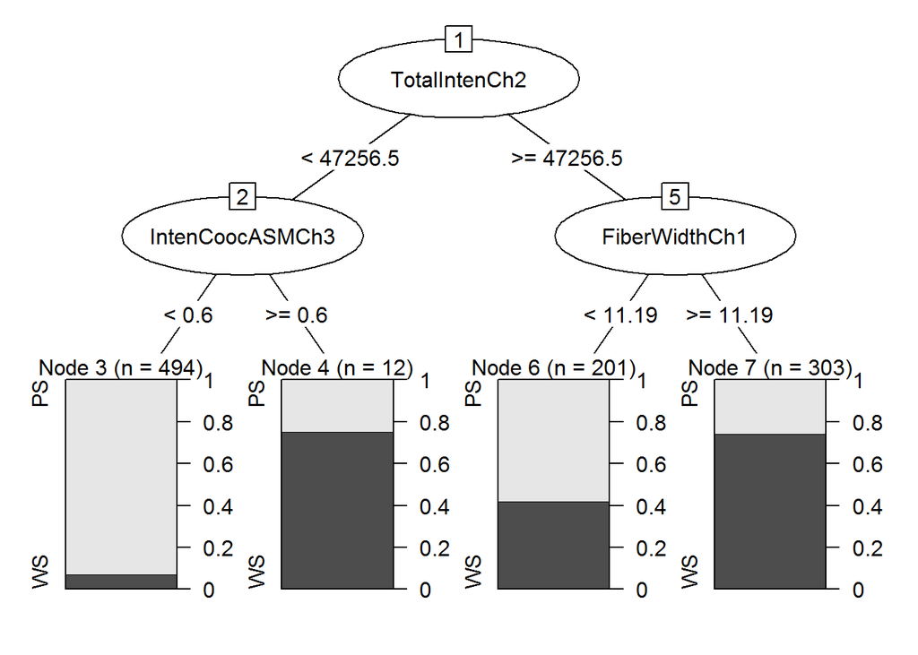

```r
tree.mod.p <- as.party(tree.mod)    # make the tree.mod object into a party object
plot(tree.mod.p)
```

## Generalized Boosted Regression Model

We build a gbm model. Note that the gbm function does not allow factor “class” variables

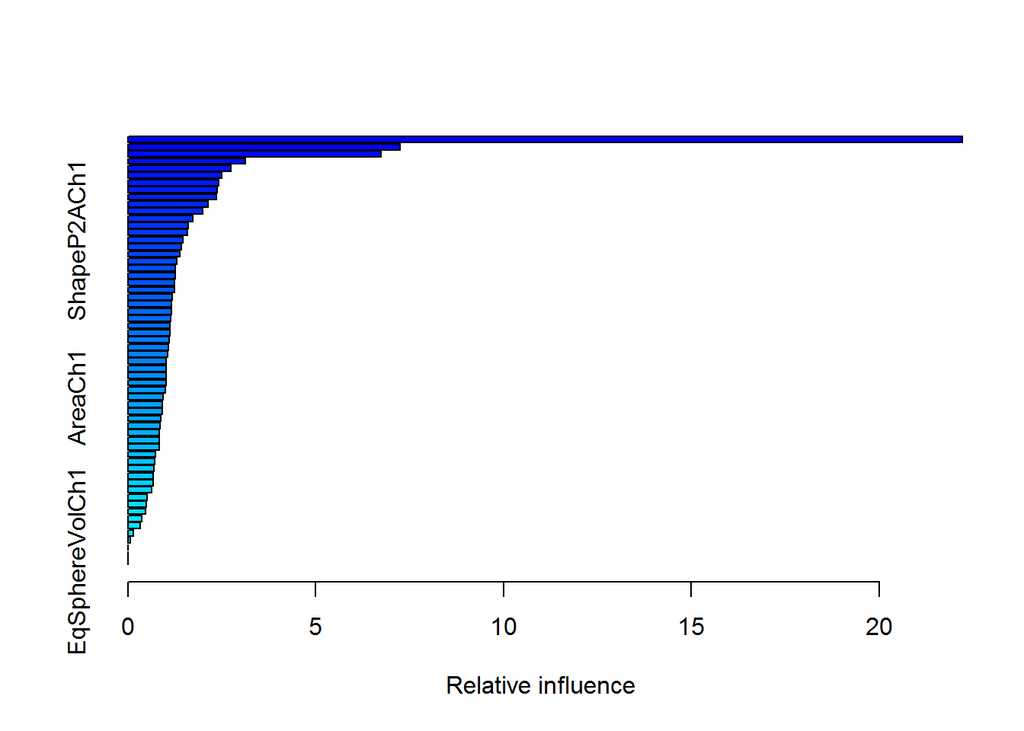

```
##                                             var  rel.inf
## TotalIntenCh2                     TotalIntenCh2 22.21262
## FiberWidthCh1                     FiberWidthCh1  7.24224
## Cell                                       Cell  6.74028
## ConvexHullAreaRatioCh1   ConvexHullAreaRatioCh1  3.13507
## AvgIntenCh2                         AvgIntenCh2  2.74235
## AvgIntenCh1                         AvgIntenCh1  2.50682
## VarIntenCh4                         VarIntenCh4  2.42247
## TotalIntenCh1                     TotalIntenCh1  2.36738
## SkewIntenCh1                       SkewIntenCh1  2.35340
## IntenCoocContrastCh3       IntenCoocContrastCh3  2.13879
## EntropyIntenCh1                 EntropyIntenCh1  1.98486
## KurtIntenCh1                       KurtIntenCh1  1.73293
## EqEllipseLWRCh1                 EqEllipseLWRCh1  1.59923
## SkewIntenCh4                       SkewIntenCh4  1.59332
## ShapeP2ACh1                         ShapeP2ACh1  1.45307
## DiffIntenDensityCh4         DiffIntenDensityCh4  1.42727
## EntropyIntenCh4                 EntropyIntenCh4  1.37515
## VarIntenCh1                         VarIntenCh1  1.30286
## ShapeBFRCh1                         ShapeBFRCh1  1.26332
## IntenCoocContrastCh4       IntenCoocContrastCh4  1.25579
## DiffIntenDensityCh3         DiffIntenDensityCh3  1.23235
## AngleCh1                               AngleCh1  1.23154
## TotalIntenCh3                     TotalIntenCh3  1.17286
## YCentroid                             YCentroid  1.16410
## EqEllipseProlateVolCh1   EqEllipseProlateVolCh1  1.14973
## TotalIntenCh4                     TotalIntenCh4  1.14097
## FiberAlign2Ch3                   FiberAlign2Ch3  1.11936
## XCentroid                             XCentroid  1.11599
## NeighborMinDistCh1           NeighborMinDistCh1  1.10032
## ConvexHullPerimRatioCh1 ConvexHullPerimRatioCh1  1.07725
## SkewIntenCh3                       SkewIntenCh3  1.06290
## WidthCh1                               WidthCh1  1.02494
## IntenCoocASMCh3                 IntenCoocASMCh3  1.02372
## VarIntenCh3                         VarIntenCh3  1.02168
## FiberAlign2Ch4                   FiberAlign2Ch4  1.00946
## EntropyIntenCh3                 EntropyIntenCh3  0.99440
## AreaCh1                                 AreaCh1  0.92757
## NeighborVarDistCh1           NeighborVarDistCh1  0.92476
## ShapeLWRCh1                         ShapeLWRCh1  0.92251
## EqEllipseOblateVolCh1     EqEllipseOblateVolCh1  0.88199
## IntenCoocEntropyCh3         IntenCoocEntropyCh3  0.84650
## FiberLengthCh1                   FiberLengthCh1  0.84142
## KurtIntenCh4                       KurtIntenCh4  0.83309
## IntenCoocMaxCh3                 IntenCoocMaxCh3  0.82783
## DiffIntenDensityCh1         DiffIntenDensityCh1  0.73843
## KurtIntenCh3                       KurtIntenCh3  0.72170
## LengthCh1                             LengthCh1  0.69397
## IntenCoocEntropyCh4         IntenCoocEntropyCh4  0.67748
## NeighborAvgDistCh1           NeighborAvgDistCh1  0.67706
## PerimCh1                               PerimCh1  0.62547
## AvgIntenCh3                         AvgIntenCh3  0.51187
## SpotFiberCountCh4             SpotFiberCountCh4  0.48196
## AvgIntenCh4                         AvgIntenCh4  0.47893
## IntenCoocASMCh4                 IntenCoocASMCh4  0.37558
## IntenCoocMaxCh4                 IntenCoocMaxCh4  0.32438
## SpotFiberCountCh3             SpotFiberCountCh3  0.14004
## Case                                       Case  0.05665
## EqCircDiamCh1                     EqCircDiamCh1  0.00000
## EqSphereAreaCh1                 EqSphereAreaCh1  0.00000
## EqSphereVolCh1                   EqSphereVolCh1  0.00000
```

```r
gbmTrain <- trainData
gbmTrain$Class <- ifelse(gbmTrain$Class=="PS",1,0)
gbm.mod <- gbm(formula = Class~.,           # use all variables
                distribution = "bernoulli",       # for a classification problem
                data = gbmTrain,
                n.trees = 2000,                         # 2000 boosting iterations
                interaction.depth = 7,              # 7 splits for each tree
                shrinkage = 0.01,                       # the learning rate parameter
                verbose = FALSE)                        # Do not print the details

summary(gbm.mod)            # Plot the relative inference of the variables in the model
```

This is an interesting model, but how do you select the best values for the for the three tuning parameters?  
* - n.trees  
* - interaction.depth  
* - shrinkage

Algorithm for training the model:  
* for each resampled data set do  
* hold out some samples  
* for each combination of the three tuning parameters  
* do  
* Fit the model on the resampled data set  
* Predict the values of class on the hold out samples  
* end  
* Calculate AUC: the area under the ROC for each sample  
* Select the combination of tuning parmeters that yields the best AUC

caret provides the “train” function to do all of this

The trainControl function to set the training method  
Note the default method of picking the best model is accuracy and Cohen’s Kappa

```r
ctrl <- trainControl(method="repeatedcv",               # use repeated 10fold cross validation
                        repeats=5,                          # do 5 repititions of 10-fold cv
                        summaryFunction=twoClassSummary,    # Use AUC to pick the best model
                        classProbs=TRUE)
```

Use the expand.grid to specify the search space Note that the default search grid selects 3 values of each tuning parameter

```r
#grid <- expand.grid(.interaction.depth = seq(1,7,by=2), # look at tree depths from 1 to 7
#                       .n.trees=seq(100,1000,by=50),   # let iterations go from 100 to 1,000
#                   .shrinkage=c(0.01,0.1))         # Try 2 values of the learning rate parameter

grid <- expand.grid(.interaction.depth = seq(1,4,by=2), # look at tree depths from 1 to 4
                    .n.trees=seq(10,100,by=10), # let iterations go from 10 to 100
                        .shrinkage=c(0.01,0.1))         # Try 2 values of the learning rate parameter

#
set.seed(1)
names(trainData)
```

```
##  [1] "Cell"                    "Case"
##  [3] "Class"                   "AngleCh1"
##  [5] "AreaCh1"                 "AvgIntenCh1"
##  [7] "AvgIntenCh2"             "AvgIntenCh3"
##  [9] "AvgIntenCh4"             "ConvexHullAreaRatioCh1"
## [11] "ConvexHullPerimRatioCh1" "DiffIntenDensityCh1"
## [13] "DiffIntenDensityCh3"     "DiffIntenDensityCh4"
## [15] "EntropyIntenCh1"         "EntropyIntenCh3"
## [17] "EntropyIntenCh4"         "EqCircDiamCh1"
## [19] "EqEllipseLWRCh1"         "EqEllipseOblateVolCh1"
## [21] "EqEllipseProlateVolCh1"  "EqSphereAreaCh1"
## [23] "EqSphereVolCh1"          "FiberAlign2Ch3"
## [25] "FiberAlign2Ch4"          "FiberLengthCh1"
## [27] "FiberWidthCh1"           "IntenCoocASMCh3"
## [29] "IntenCoocASMCh4"         "IntenCoocContrastCh3"
```

[output cut: 16 more lines]

```r
trainX <-trainData[,4:61]

registerDoParallel(4)       # Registrer a parallel backend for train
getDoParWorkers()
```

```
## [1] 4
```

```r
system.time(gbm.tune <- train(x=trainX,y=trainData$Class,
                method = "gbm",
                metric = "ROC",
                trControl = ctrl,
                tuneGrid=grid,
                verbose=FALSE))
```

```
##    user  system elapsed
##    0.98    0.02   28.81
```

### Tuning Results

```r
gbm.tune$bestTune
```

```
##    .interaction.depth .n.trees .shrinkage
## 34                  3       70        0.1
```

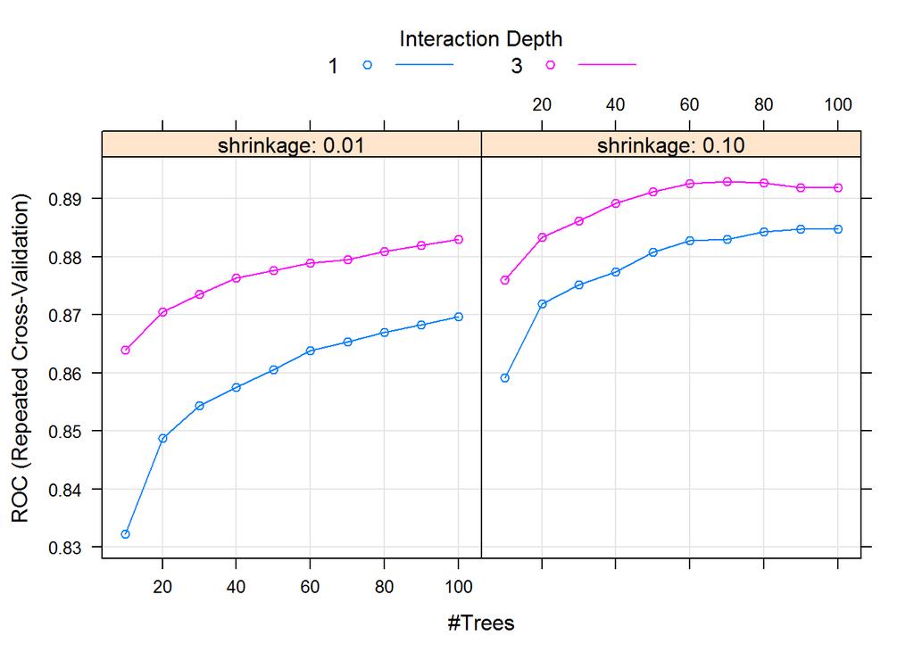

```r
plot(gbm.tune)          # Plot the performance of the training models
```

```r
res <- gbm.tune$results
names(res) <- c("depth","trees", "shrinkage","ROC", "Sens","Spec", "sdROC", "sdSens", "seSpec")
res
```

```
##    depth trees shrinkage    ROC   Sens     Spec   sdROC   sdSens  seSpec
## 1      1    10      0.01 0.8323 1.0000 0.000000 0.04102 0.000000 0.00000
## 2      1    10      0.10 0.8592 0.8965 0.544111 0.03697 0.039348 0.09247
## 3      1    20      0.01 0.8488 1.0000 0.000000 0.03856 0.000000 0.00000
## 4      1    20      0.10 0.8719 0.8673 0.641540 0.03140 0.040952 0.07036
## 5      1    30      0.01 0.8544 1.0000 0.000000 0.03595 0.000000 0.00000
## 6      1    30      0.10 0.8752 0.8573 0.675683 0.03110 0.041683 0.08184
## 7      1    40      0.01 0.8575 1.0000 0.000000 0.03557 0.000000 0.00000
## 8      1    40      0.10 0.8774 0.8591 0.687095 0.03099 0.042712 0.08199
## 9      1    50      0.01 0.8605 1.0000 0.000000 0.03425 0.000000 0.00000
## 10     1    50      0.10 0.8808 0.8631 0.693365 0.02902 0.043332 0.08490
## 11     1    60      0.01 0.8638 0.9982 0.006286 0.03262 0.012856 0.04445
## 12     1    60      0.10 0.8828 0.8610 0.696222 0.02858 0.043093 0.08573
## 13     1    70      0.01 0.8654 0.9436 0.359063 0.03239 0.041463 0.10972
## 14     1    70      0.10 0.8830 0.8619 0.697937 0.02824 0.043130 0.08259
```

[output cut: 26 more lines]

### GBM Model Predictions and Performance

Make predictions using the test data set

```r
testX <- testData[,4:61]
gbm.pred <- predict(gbm.tune,testX)
head(gbm.pred)
```

```
## [1] PS WS PS WS PS PS
## Levels: PS WS
```

Look at the confusion matrix

```r
confusionMatrix(gbm.pred,testData$Class)
```

```
## Confusion Matrix and Statistics
##
##           Reference
## Prediction  PS  WS
##         PS 548  94
##         WS  93 274
##
##                Accuracy : 0.815
##                  95% CI : (0.789, 0.838)
##     No Information Rate : 0.635
##     P-Value [Acc > NIR] : <2e-16
##
##                   Kappa : 0.6
##  Mcnemar's Test P-Value : 1
##
##             Sensitivity : 0.855
##             Specificity : 0.745
##          Pos Pred Value : 0.854
##          Neg Pred Value : 0.747
##              Prevalence : 0.635
##          Detection Rate : 0.543
##    Detection Prevalence : 0.636
##
##        'Positive' Class : PS
##
```

Draw the ROC curve

```r
gbm.probs <- predict(gbm.tune,testX,type="prob")
head(gbm.probs)
```

```
##        PS      WS
## 1 0.69106 0.30894
## 2 0.41743 0.58257
## 3 0.94757 0.05243
## 4 0.05041 0.94959
## 5 0.96228 0.03772
## 6 0.63196 0.36804
```

```r
gbm.ROC <- roc(predictor=gbm.probs$PS,
            response=testData$Class,
                levels=rev(levels(testData$Class)))
gbm.ROC
```

```
##
## Call:
## roc.default(response = testData$Class, predictor = gbm.probs$PS,     levels = rev(levels(testData$Class)))
##
## Data: gbm.probs$PS in 368 controls (testData$Class WS) < 641 cases (testData$Class PS).
## Area under the curve: 0.895
```

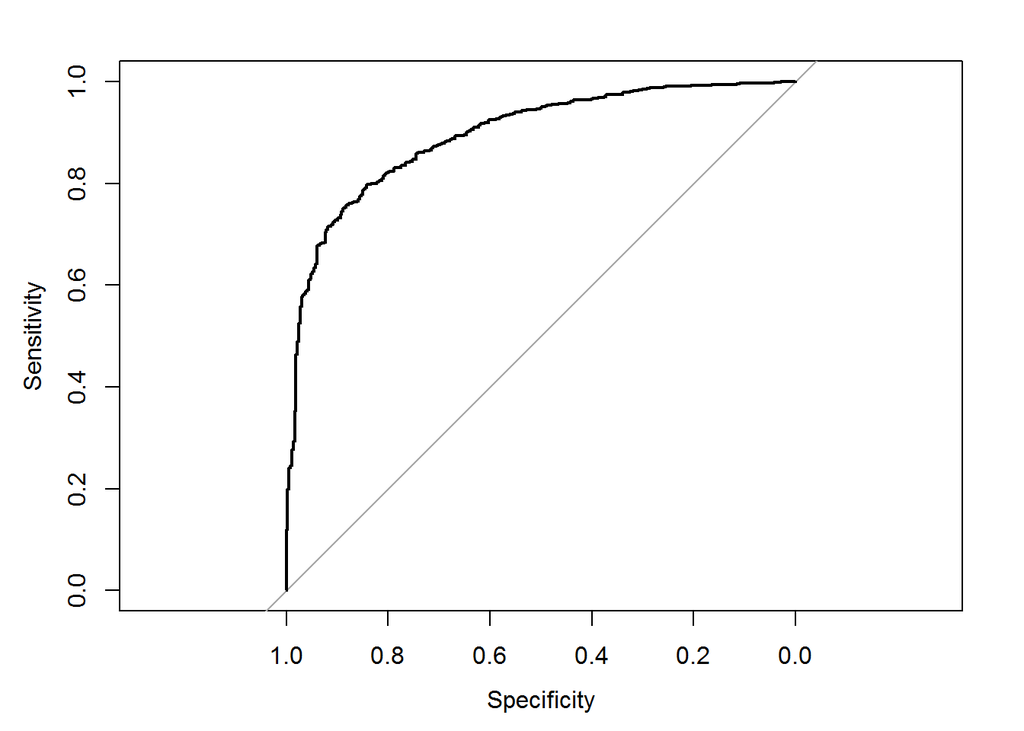

```
##
## Call:
## roc.default(response = testData$Class, predictor = gbm.probs$PS,     levels = rev(levels(testData$Class)))
##
## Data: gbm.probs$PS in 368 controls (testData$Class WS) < 641 cases (testData$Class PS).
## Area under the curve: 0.895
```

```r
plot(gbm.ROC)
```

Plot the propability of poor segmentation

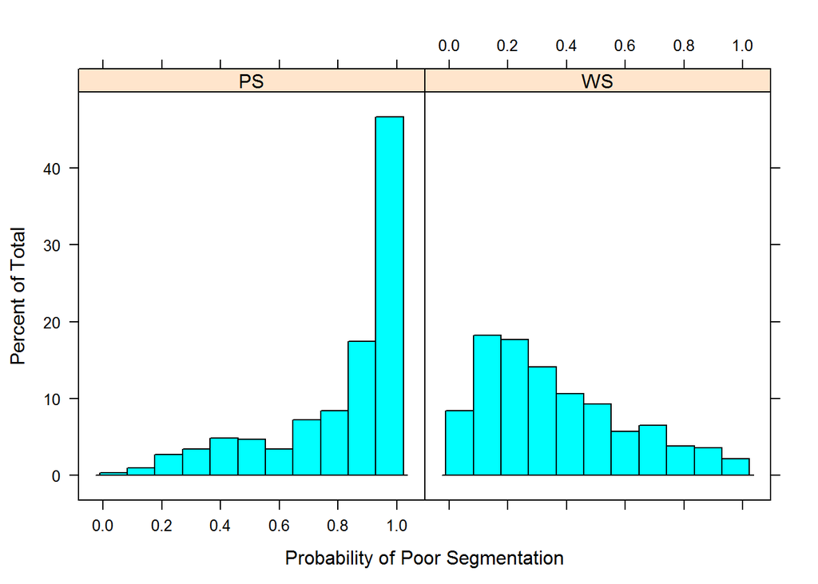

```r
histogram(~gbm.probs$PS|testData$Class,xlab="Probability of Poor Segmentation")
```

## SUPPORT VECTOR MACHINE MODEL

We follow steps similar to those above to build a SVM mocel

```r
set.seed(1)
registerDoParallel(4,cores=4)
getDoParWorkers()
```

```
## [1] 4
```

```r
system.time(
  svm.tune <- train(x=trainX,
                    y= trainData$Class,
                    method = "svmRadial",
                    tuneLength = 9,                 # 9 values of the cost function
                    preProc = c("center","scale"),
                    metric="ROC",
                    trControl=ctrl) # same as for gbm above
)
```

```
##    user  system elapsed
##    3.21    0.11  223.07
```

```r
svm.tune
```

```
## 1010 samples
##   58 predictors
##    2 classes: 'PS', 'WS'
##
## Pre-processing: centered, scaled
## Resampling: Cross-Validation (10 fold, repeated 5 times)
##
## Summary of sample sizes: 910, 909, 909, 908, 909, 909, ...
##
## Resampling results across tuning parameters:
##
##   C    ROC  Sens  Spec  ROC SD  Sens SD  Spec SD
##   0.2  0.9  0.9   0.7   0.03    0.04     0.09
##   0.5  0.9  0.9   0.7   0.03    0.04     0.09
##   1    0.9  0.9   0.7   0.02    0.03     0.08
##   2    0.9  0.9   0.7   0.02    0.03     0.08
##   4    0.9  0.9   0.7   0.03    0.03     0.08
##   8    0.9  0.9   0.7   0.03    0.04     0.08
##   20   0.9  0.9   0.6   0.03    0.04     0.07
##   30   0.9  0.9   0.6   0.03    0.04     0.07
##   60   0.9  0.9   0.6   0.03    0.04     0.07
##
## Tuning parameter 'sigma' was held constant at a value of 0.02
## ROC was used to select the optimal model using  the largest value.
## The final values used for the model were C = 1 and sigma = 0.02.
```

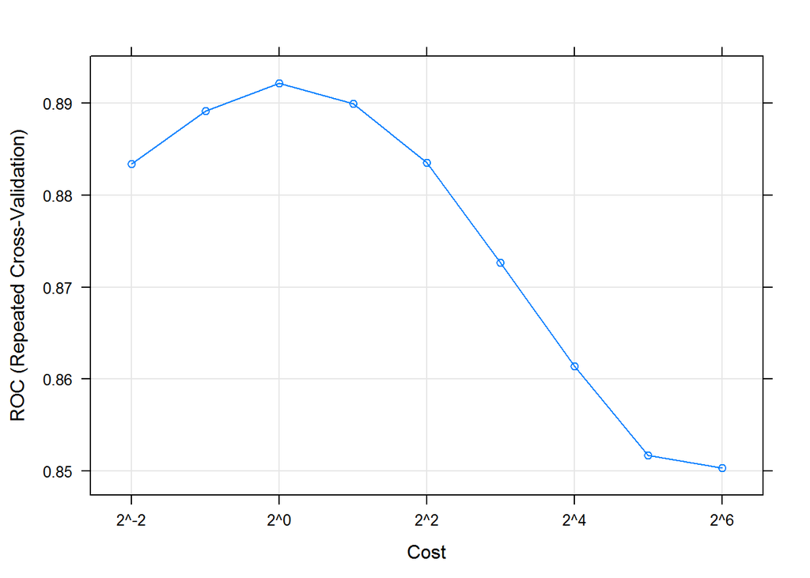

```r
# Plot the SVM results
plot(svm.tune,
  metric="ROC",
    scales=list(x=list(log=2)))
```

```r
#---------------------------------------------------
# SVM Predictions
svm.pred <- predict(svm.tune,testX)
head(svm.pred)
```

```
## [1] WS WS PS WS PS PS
## Levels: PS WS
```

```r
confusionMatrix(svm.pred,testData$Class)
```

```
## Confusion Matrix and Statistics
##
##           Reference
## Prediction  PS  WS
##         PS 559 106
##         WS  82 262
##
##                Accuracy : 0.814
##                  95% CI : (0.788, 0.837)
##     No Information Rate : 0.635
##     P-Value [Acc > NIR] : <2e-16
##
##                   Kappa : 0.592
##  Mcnemar's Test P-Value : 0.0935
##
##             Sensitivity : 0.872
##             Specificity : 0.712
##          Pos Pred Value : 0.841
##          Neg Pred Value : 0.762
##              Prevalence : 0.635
##          Detection Rate : 0.554
##    Detection Prevalence : 0.659
##
##        'Positive' Class : PS
##
```

## Comparing Models

Having set the seed to 1 before running gbm.tune and svm.tune we have generated paired samples (See Hothorn at al, “The design and analysis of benchmark experiments-Journal of Computational and Graphical Statistics (2005) vol 14 (3) pp 675-699) and are in a position to compare models using a resampling technique.

The resamples function in caret collates the resampling results from the two models

```r
rValues <- resamples(list(svm=svm.tune,gbm=gbm.tune))
rValues$values
```

```
##       Resample svm~ROC svm~Sens svm~Spec gbm~ROC gbm~Sens gbm~Spec
## 1  Fold01.Rep1  0.9046   0.9077   0.7429  0.9046   0.8769   0.7143
## 2  Fold01.Rep2  0.9139   0.8939   0.6857  0.9022   0.8333   0.8286
## 3  Fold01.Rep3  0.8922   0.9242   0.7143  0.8922   0.8788   0.7429
## 4  Fold01.Rep4  0.9338   0.9242   0.7429  0.9459   0.8485   0.8286
## 5  Fold01.Rep5  0.8632   0.9091   0.6000  0.8485   0.8485   0.6857
## 6  Fold02.Rep1  0.9004   0.9242   0.5143  0.8762   0.9091   0.4857
## 7  Fold02.Rep2  0.8970   0.8788   0.6571  0.8918   0.8788   0.6857
## 8  Fold02.Rep3  0.9373   0.8788   0.7500  0.9318   0.8788   0.7500
## 9  Fold02.Rep4  0.8918   0.8939   0.6571  0.8675   0.8788   0.6000
## 10 Fold02.Rep5  0.9030   0.8788   0.7714  0.8857   0.8788   0.8571
## 11 Fold03.Rep1  0.9143   0.8636   0.7714  0.9100   0.8333   0.8571
## 12 Fold03.Rep2  0.8857   0.9545   0.6571  0.8814   0.9091   0.7143
## 13 Fold03.Rep3  0.8749   0.9091   0.4857  0.8515   0.8939   0.5714
## 14 Fold03.Rep4  0.8935   0.8636   0.7429  0.8762   0.7879   0.7143
```

[output cut: 36 more lines]

```r
summary(rValues)
```

```
##
## Call:
## summary.resamples(object = rValues)
##
## Models: svm, gbm
## Number of resamples: 50
##
## ROC
##      Min. 1st Qu. Median  Mean 3rd Qu.  Max. NA's
## svm 0.849   0.875  0.892 0.892   0.909 0.938    0
## gbm 0.842   0.875  0.892 0.893   0.910 0.953    0
##
## Sens
##      Min. 1st Qu. Median  Mean 3rd Qu.  Max. NA's
## svm 0.818   0.864  0.894 0.890   0.909 0.955    0
## gbm 0.773   0.822  0.878 0.864   0.894 0.955    0
##
## Spec
##      Min. 1st Qu. Median  Mean 3rd Qu.  Max. NA's
## svm 0.486   0.639  0.690 0.685   0.743 0.800    0
## gbm 0.486   0.686  0.729 0.730   0.800 0.886    0
```

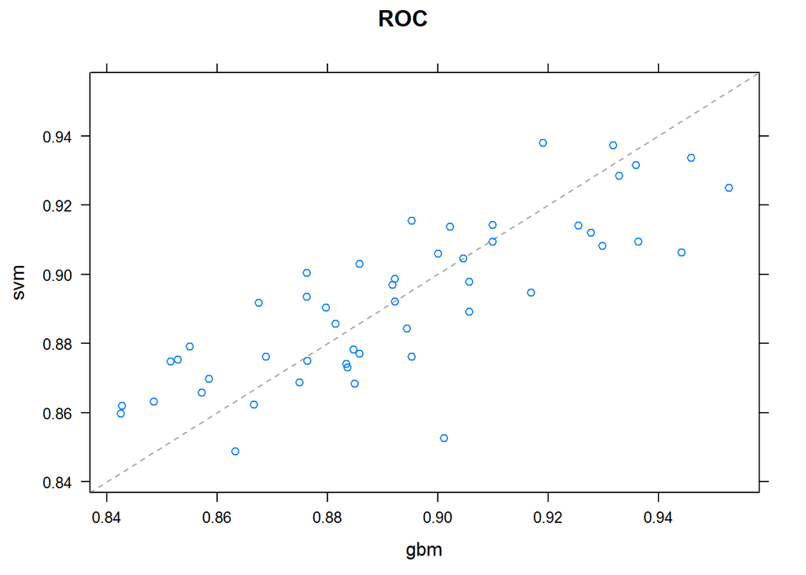

```r
xyplot(rValues,metric="ROC")        # scatter plot
```

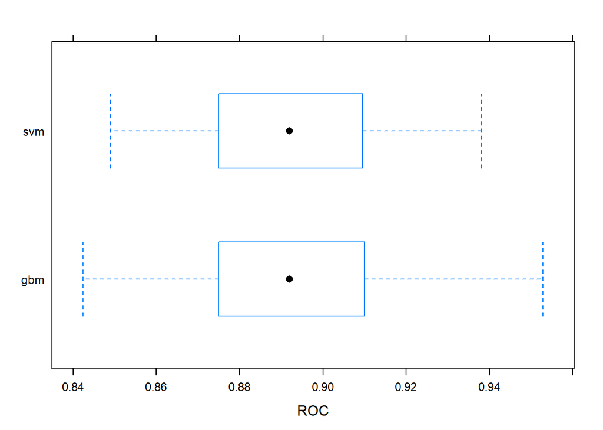

```r
bwplot(rValues,metric="ROC")            # boxplot
```

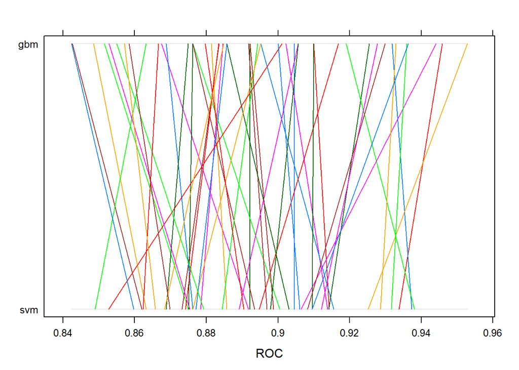

```r
parallelplot(rValues,metric="ROC")  # parallel plot
```

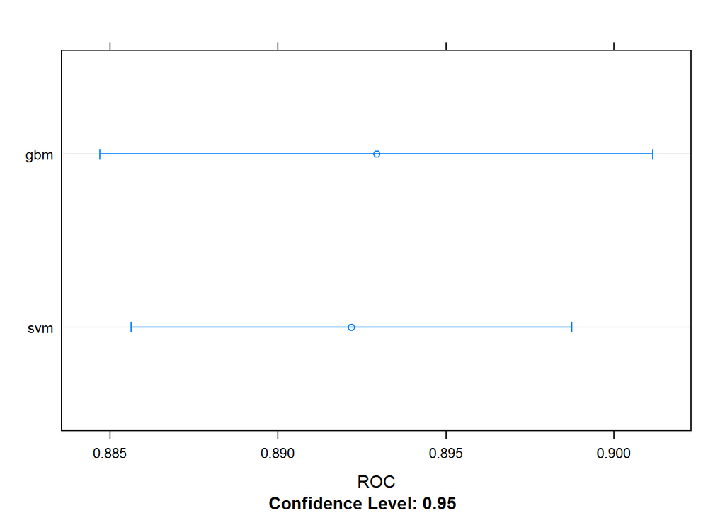

```r
dotplot(rValues,metric="ROC")           # dotplot
```

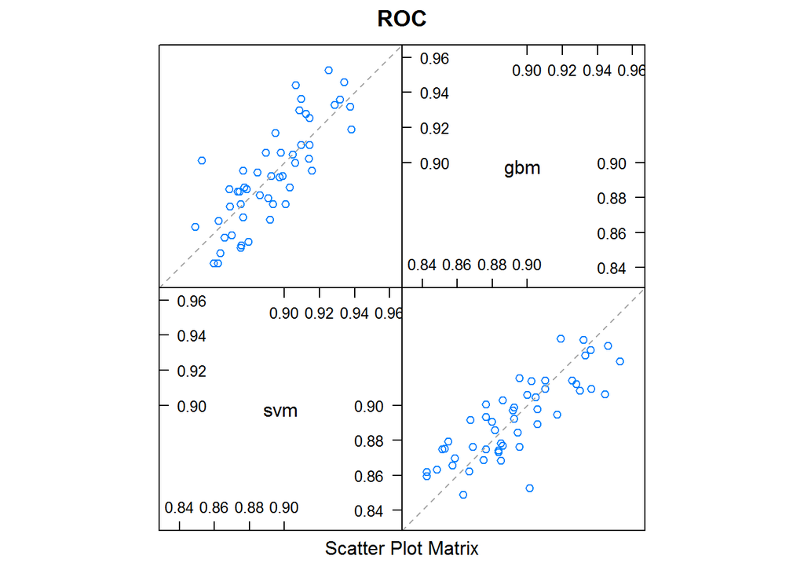

```r
splom(rValues,metric="ROC")
```